# W&L Courses

# The Data

Let’s get started by loading some “real world” data: a table of course enrollments for this academic year at W&L.

```r
enrollments <- read.table("/home/gregg/cs102/enrollments.txt")
```

You can look at an overview of this `data.frame` in RStudio by clicking on it in the environment viewer or with:

```r
View(enrollments)
```

Hopefully most of the column names in this data frame are self-explanatory.

The first thing you should always do when exploring a new data set is get a sense of the data landscape. The best way to do this is with a visualization…

# Basic Plotting

R features an auto-magical graphing function named `plot`. You can pass it virtually anything and it will try to draw you a picture.

For example, you can pass it two `numeric` vectors and it will give you a scatter plot:

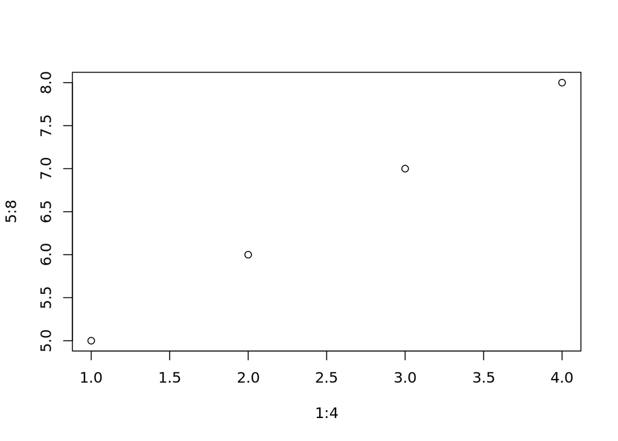

```r
plot(1:4, 5:8)
```

Or you can pass it a function and it will draw it’s result with reasonable limits:

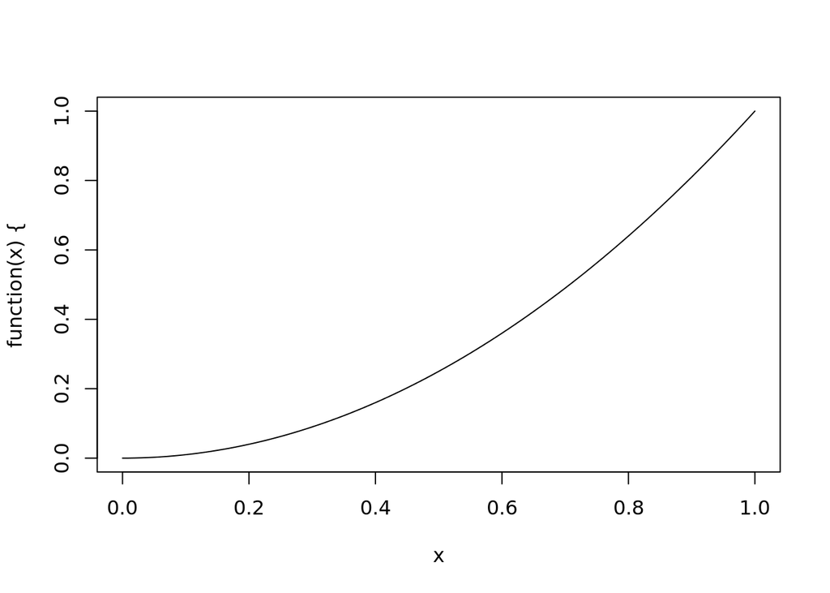

```r
plot(function(x) { x^2 })
```

Or you can pass it a return object from an analysis function like `density` which performs a kernal smoothing on a distribution of values, for example our enrollment counts:

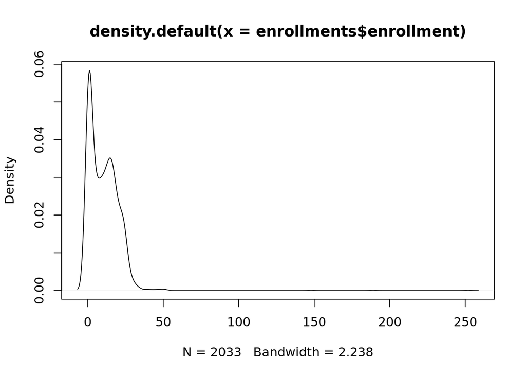

```r
plot(density(enrollments$enrollment))
```

The greatest strength of `plot` is that it will almost always draw something; the greatest weakness of `plot` is that it can be hard to understand what it picked or to make the look pretty (publication quality). In general, when you’re first playing around with a new kind of analysis in R it’s a good idea to pass results out to `plot` to see what you get. The resulting graph is usually useful, if a bit ugly.

However, in today’s excercise I’ll introduce you to an alternative plugin tool that is among the most widely used in R…

# ggplot2: Welcome to the HadleyVerse

The philosphy behind the stock `plot` function in R is that it should nearly always produce a result at all costs to sanity. Under the hood that result can be customized (see `?par` for graphical parameters), but trying to do so might lead you down a bit of a rabbit hole.

One of the most prolific and influentical contributors to the R software ecosystem has been [Hadely Wickham](http://had.co.nz/). The package [`ggplot2`](http://docs.ggplot2.org/current/) is his second and most widely adopted attempt to bring sanity back to visualization in R. Most importantly, the defaults nearly always give you something pretty.

Here’s the `ggplot2` version of that last graph:

```r
library(ggplot2)
```

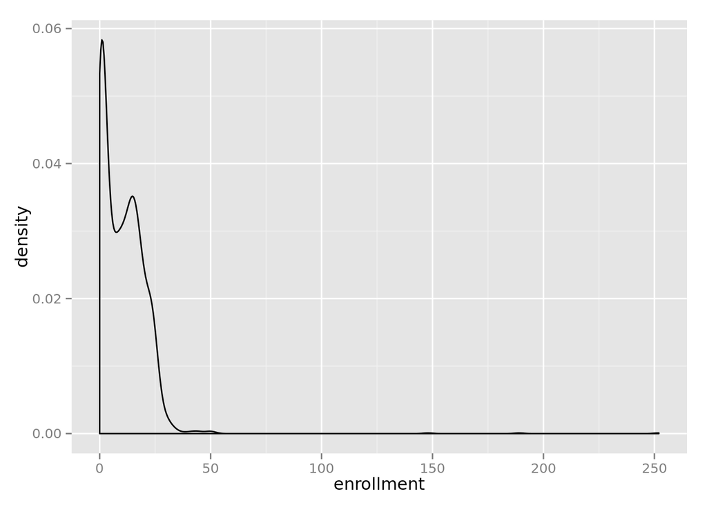

```r
ggplot(enrollments, aes(enrollment)) + geom_density()
```

The same plot, but much prettier. This package is an implementation of a “Grammar of Graphics” (gg) proposed by the great data analyst [Leland Wilkinson](http://en.wikipedia.org/wiki/Leland_Wilkinson). The idea here is simple: separate *what* you are visualzing from *how* you are visualzing it.

Let’s break down that last call into it’s parts:

```r
viz <- ggplot(enrollments, aes(enrollment))
```

The first argument to `ggplot` is data to use for our visualization; usually a data frame. The `aes` function sets up aesthetic mappings. In this case, we state that we are interested in the `enrollment` variable in our data set.

Finally, we apply a visualization mechanism (“geom”s) to our values of interest using the `+` (add) operator:

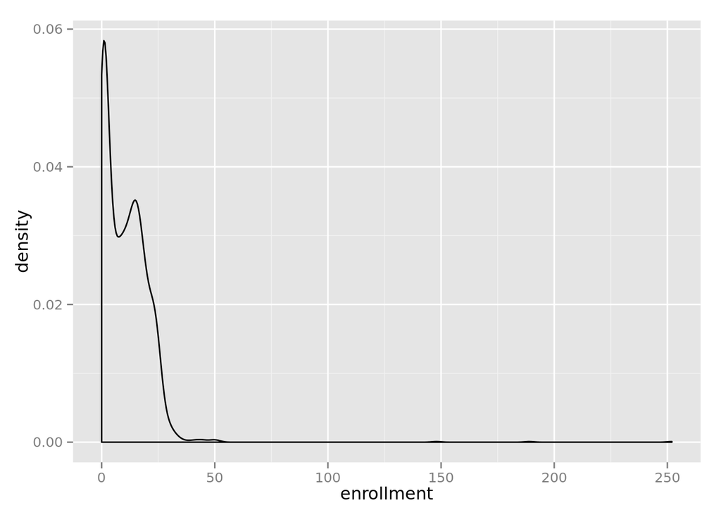

```r
viz + geom_density()
```

But what would this graphic look like if we used a histogram instead?

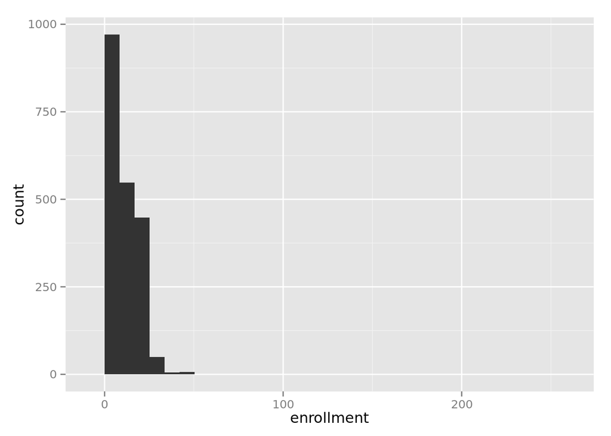

```r
viz + geom_histogram()
```

The approach with this “Grammar of Graphics” implementation is to offer both [modularity](http://en.wikipedia.org/wiki/Modular_programming) and [composibility](http://en.wikipedia.org/wiki/Composability): break what you want to visualize into fundamental parts and then offer a number of ways to assemble those parts into a data projection. It works really well when you are playing with visualizations in an interactive R session.

Let’s see a practical example. Have you noticed that most values in our data set fall below an enrollment of 50? Yet we’re scaling the x-axis to include some extreme outliers. We can add a simple graphical declaration to our `ggplot` to focus the view:

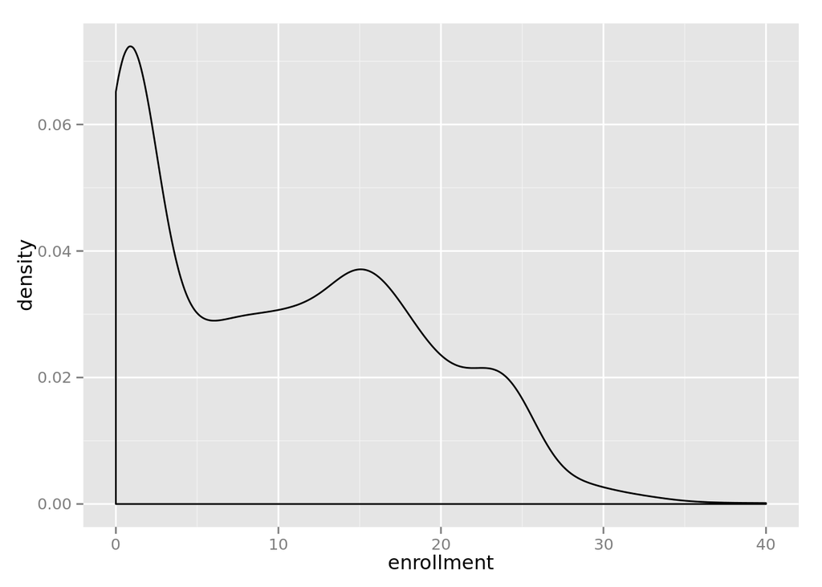

```r
viz + geom_density() + xlim(0, 40)
```

# Cleaning input data

Above, we arrived at a much more informative view of our class enrollment data by constraining the x-axis range for our density plot. This suggest that there may be some extreme outliers in the enrollment data set that we will want to cull if we can verify that they are un-interesting data points.

Let’s take a look at our most enrolled courses, to see if they are really all of interest to us. You can use the `order` function to easily sort rows in a `data.frame`:

```r
ordered <- enrollments[order(enrollments$enrollment, decreasing = TRUE),]
head(ordered[, c("number", "title", "enrollment")], n = 10)
```

```
##                              number                     title enrollment
## 1934 INTR-995-01                                SPRING OPTION        252
## 1656 PE-XXX-01                      GRAD REQUIREMENT COMPLETE        189
## 715  PE-XXX-01                      GRAD REQUIREMENT COMPLETE        148
## 1463 MUS-110-01                            UNIVERSITY SINGERS         51
## 1370 INTR-998-01                        APPROVED STUDY ABROAD         50
## 1935 INTR-998-01                        APPROVED STUDY ABROAD         50
## 532  MUS-110-01                            UNIVERSITY SINGERS         49
## 431  INTR-998-01                        APPROVED STUDY ABROAD         45
## 1287 GEOL-104-01                            PLANETARY GEOLOGY         45
## 83   BIOL-220-01                                     GENETICS         44
```

To get a quick view of the most highly enrolled entries, in the first line we’ve re-ordered the data to sort by enrollment by indexing our `data.frame` with the result of ther `order` function. On the next line, we use the `head` function to just print the first 10 rows of the re-ordered data (you can use `tail` to print the last rows of a table). We’ve also included some column filtering to make the results easier to look out (alternatively, you can use the `View` function if you’re workig in RStudio).

Looking at the results it’s easy to see why the tail of our enrollment distribution was spread out so far: bogus highly enrolled course listings like “Spring Option.” Let’s use indexing to filter out these entries so that we’re just working with real courses:

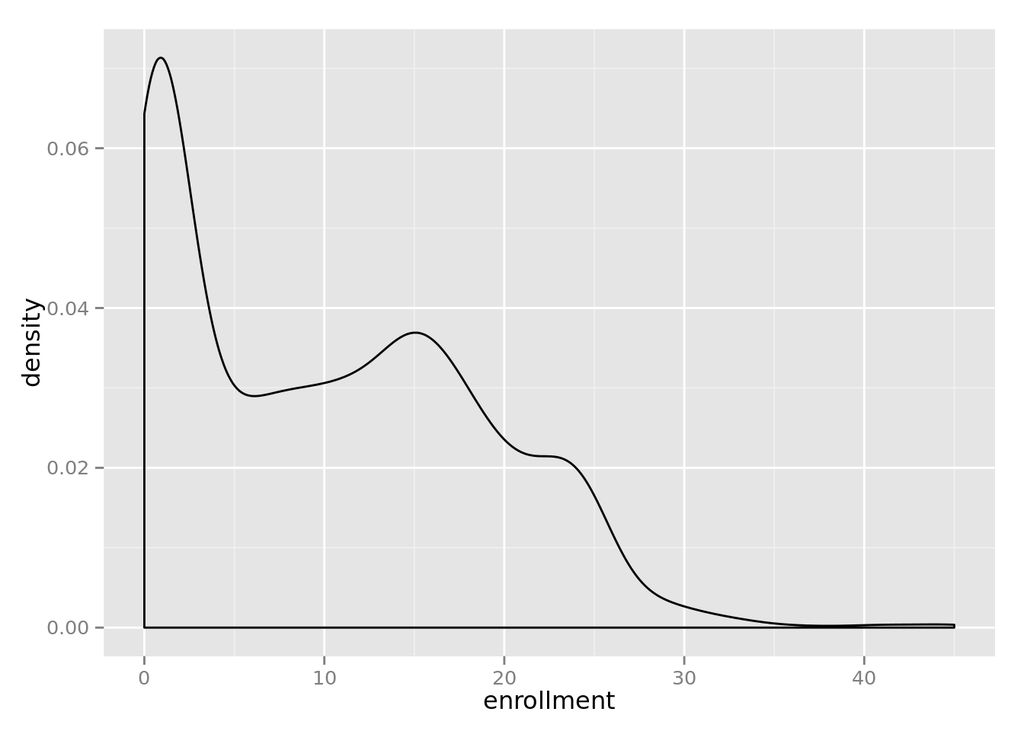

```r
courses <- enrollments[enrollments$enrollment < 49,]
ggplot(courses, aes(enrollment)) + geom_density()
```

# Summary statistics

In addition to using visualizations like histograms and density distributions to get a sense of value dispersion in a data set, another good place to start with a new data set is to compute standard summary statistics. Like `plot`, the built in `summary` function will try to be smart about what it does based on the kinds of values you pass to it. For example, we can pass in a single vector of numeric values:

```r
summary(courses$enrollment)
```

```
##    Min. 1st Qu.  Median    Mean 3rd Qu.    Max.
##    0.00    1.00    9.00   10.09   16.75   45.00
```

We can also pass in a vector of categorical values (a `factor` in statistics lingo):

```r
summary(courses$fdr)
```

```
##        FL   FM   FP   FW   HA   HL   HU   SC   SL   SS
## 1277   25   25  134   23   96   80  157   21   72  116
```

When we passed in a vector of numeric values we were given information about the mean, median, etc; when we passed in a vector of categorical values `summary` changed it’s approach and reported counts for each category. We can also pass in an entire data.frame:

```r
summary(courses)
```

[output not shown]

# Composing visualizations

`ggplot2` is designed to make it easy to interactively build interesting data visualizations by layering components. Let’s say we’re interested in how many people have/are taking classes in each of the FDR areas this year. We can enhance our simple distribution plots by layering in coloring using the categorical FDR values:

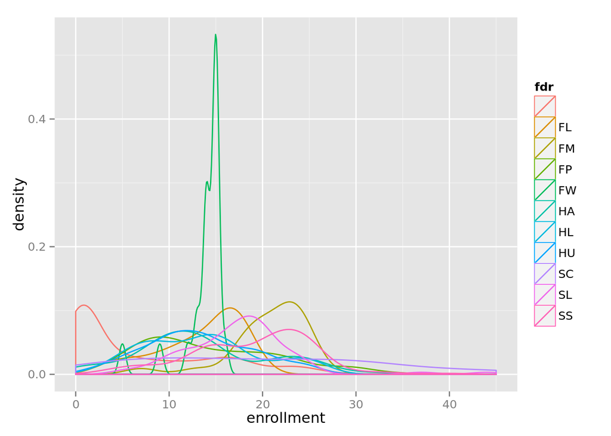

```r
p <- ggplot(courses, aes(enrollment))
p + geom_density(aes(color = fdr))
```

Instead of using line color, we can use fill color:

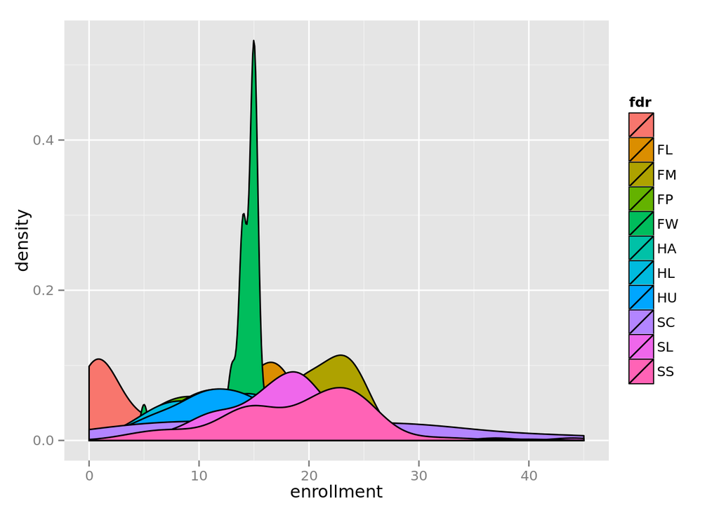

```r
p + geom_density(aes(fill = fdr))
```

This plot is a little hard to look at because the distributions are on top of eachother, so let’s set a transparency value (alpha channel):

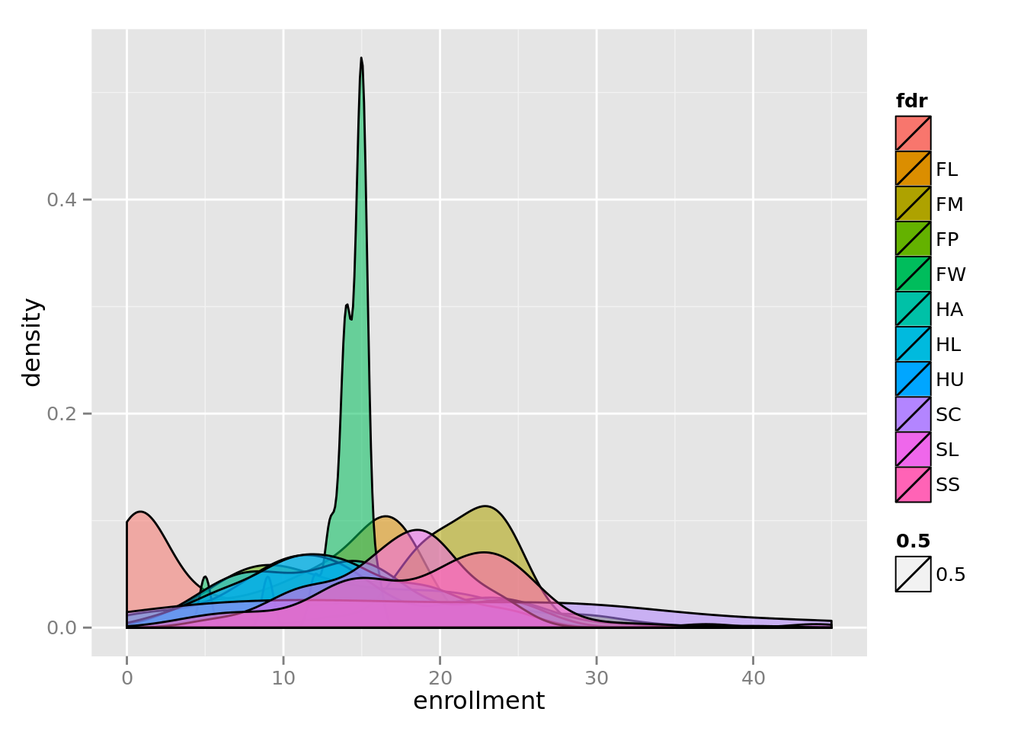

```r
p + geom_density(aes(fill = fdr, alpha = 0.5))
```

# Interactions between quantitative variables

Scatter plots are common mechanisms to use to visualize the interaction between quantitative variables. For example, we can ask how well our expected enrollments correlated with actual enrollments:

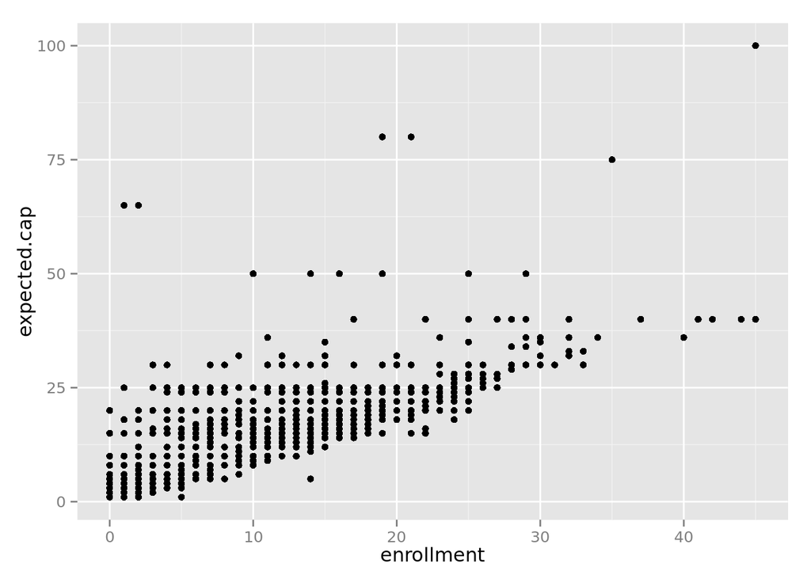

```r
p2 <- ggplot(courses, aes(enrollment, expected.cap))
p2 + geom_point()
```

Are any outliers correlated with FDR areas?

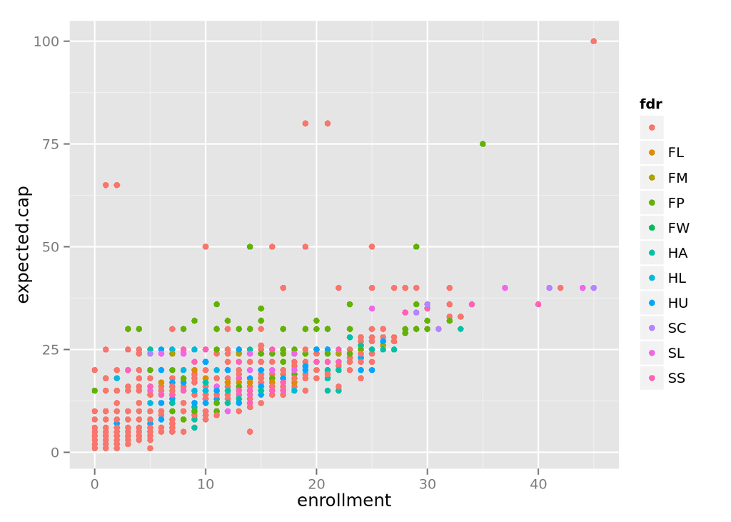

```r
p2 + geom_point(aes(color = fdr))
```

How about department?

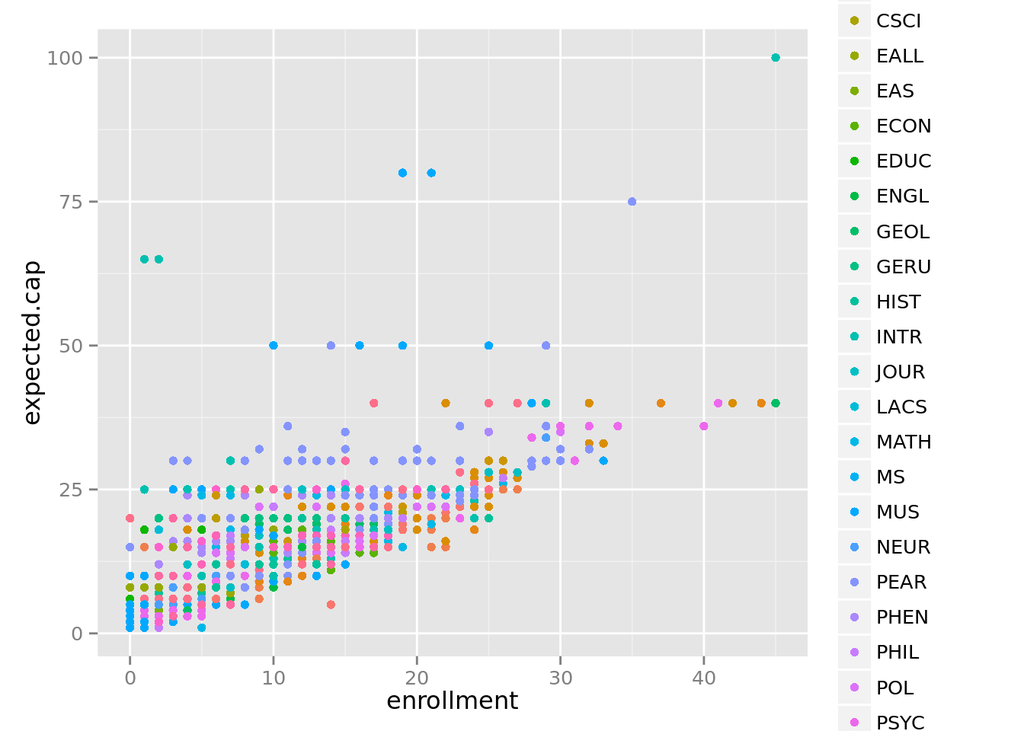

```r
p2 + geom_point(aes(color = department))
```

```r
fit <- lm(expected.cap ~ enrollment, data = courses)
fit
```

```
##
## Call:
## lm(formula = expected.cap ~ enrollment, data = courses)
##
## Coefficients:
## (Intercept)   enrollment
##      6.6931       0.7948
```

We can get more information about the fit with `summary`:

```r
summary(fit)
```

```
##
## Call:
## lm(formula = expected.cap ~ enrollment, data = courses)
##
## Residuals:
##     Min      1Q  Median      3Q     Max
## -12.820  -3.615  -1.217   2.718  58.206
##
## Coefficients:
##             Estimate Std. Error t value Pr(>|t|)
## (Intercept)  6.69311    0.20224   33.09   <2e-16 ***
## enrollment   0.79478    0.01528   52.01   <2e-16 ***
## ---
## Signif. codes:  0 '***' 0.001 '**' 0.01 '*' 0.05 '.' 0.1 ' ' 1
##
## Residual standard error: 5.895 on 2024 degrees of freedom
## Multiple R-squared:  0.572,  Adjusted R-squared:  0.5718
## F-statistic:  2705 on 1 and 2024 DF,  p-value: < 2.2e-16
```

If we want to visualize or model along side our data we can extract the coefficients (slope and intercept in this case) and use an “abline” to plot the function:

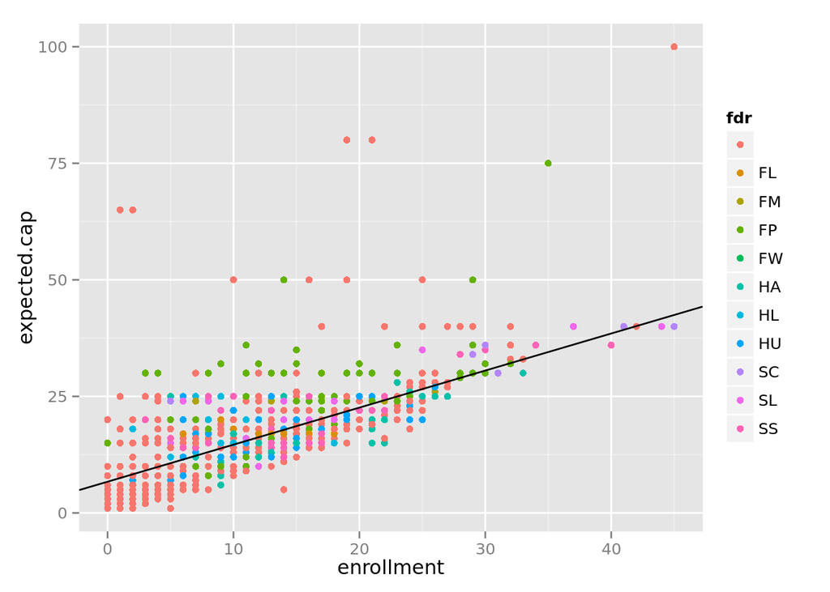

```r
b <- coefficients(fit)[1]
m <- coefficients(fit)[2]
p2 + geom_point(aes(color = fdr)) + geom_abline(slope = m, intercept = b)
```